# LGBTQI+ Hate Crime Analysis — 03: Statistical Analysis

Guilherme Arpi

2026-09-29

## Overview

Six formal statistical tests are performed on the cleaned pipeline outputs. Each test is chosen to answer a specific research question about LGBTQI+ hate crime patterns.

| # | Test | Research Question |
| --- | --- | --- |
| 1 | Mann-Kendall + Sen’s slope | Is there a significant monotonic trend in annual incident counts? |
| 2 | Welch’s t-test + Cohen’s d | Do states with hate crime laws have different victimisation rates? |
| 3 | CAGR by subgroup | Which bias categories grew the fastest between 1991 and 2024? |
| 4 | Spearman correlation matrix | How do rate, Gini, population, and law level relate? |
| 5 | OLS multiple regression | What independently predicts state-level victimisation rate? |
| 6 | Chi-square test | Is the violent/non-violent split independent of season? |

Results are printed inline and also written to `reports/statistical_findings.txt`.

## Setup

```r
library(tidyverse)
library(scales)
library(patchwork)
library(broom)
```

```r
BASE_DIR    <- getwd()
DATA_DIR    <- file.path(BASE_DIR, "data")
CHARTS_DIR  <- file.path(BASE_DIR, "charts")
REPORTS_DIR <- file.path(BASE_DIR, "reports")
dir.create(REPORTS_DIR, showWarnings = FALSE, recursive = TRUE)

theme_hate <- function() {
  theme_minimal(base_size = 11) +
    theme(
      plot.title       = element_text(face = "bold", size = 13, colour = "#1A1A1A"),
      plot.subtitle    = element_text(size = 10, colour = "#555555"),
      axis.text        = element_text(colour = "#444444"),
      axis.title       = element_text(size = 10, colour = "#444444"),
      panel.grid.minor = element_blank(),
      panel.grid.major = element_line(colour = "#EEEEEE"),
      plot.background  = element_rect(fill = "white", colour = NA),
      panel.background = element_rect(fill = "#FAFAFA", colour = NA)
    )
}

save_chart <- function(plot, filename, width = 9, height = 5) {
  ggsave(file.path(CHARTS_DIR, filename), plot = plot,
         width = width, height = height, dpi = 150, bg = "white")
}

report_lines <- c(strrep("=", 72),
                  "LGBTQI+ HATE CRIME ANALYSIS — STATISTICAL FINDINGS",
                  strrep("=", 72), "")
add_result <- function(...) {
  report_lines <<- c(report_lines, ..., strrep("-", 72), "")
}
```

```r
full <- read_csv(file.path(DATA_DIR, "lgbtq_hate_crimes_full.csv"),
                 show_col_types = FALSE) |>
  rename_with(str_to_upper)

sy <- read_csv(file.path(DATA_DIR, "state_year_aggregate.csv"),
               show_col_types = FALSE) |>
  rename_with(str_to_upper)

# Time-varying law lookup — one row per state × year (1991–2024)
law_lookup <- tryCatch(
  read_csv(file.path(DATA_DIR, "state_law_panel.csv"), show_col_types = FALSE) |>
    rename(STATE_NAME = State, DATA_YEAR = Year) |>
    select(STATE_NAME, DATA_YEAR, LAW_LEVEL, HC_LAW_SO, HC_LAW_GI),
  error = function(e) {
    message("state_law_panel.csv not found — law_lookup unavailable.")
    NULL
  }
)

if (!"YEAR" %in% names(full) && "DATA_YEAR" %in% names(full))
  full <- full |> rename(YEAR = DATA_YEAR)

cat(sprintf("Loaded %s incident rows | %s state-year rows\n",
            format(nrow(full), big.mark=","),
            format(nrow(sy),   big.mark=",")))
```

```
## Loaded 45,318 incident rows | 1,543 state-year rows
```

## Test 1 — Mann-Kendall Trend Test

**Rationale:** A simple linear regression trend test assumes constant variance and normality. Annual hate crime counts violate both — they are right-skewed counts with non-constant variance over a 34-year window. The Mann-Kendall test is non-parametric and tests only for a *monotonic* trend (consistently up or down), making it more appropriate here.

**Sen’s slope** is the median of all pairwise slopes between observations and provides a robust estimate of the trend magnitude in the same units as the data (incidents/year).

```r
yearly <- full |> count(YEAR, name = "INCIDENTS") |> arrange(YEAR)
x <- yearly$INCIDENTS
n <- length(x)

s_val <- sum(sapply(seq_len(n - 1), function(i) sum(sign(x[(i+1):n] - x[i]))))
var_s  <- n * (n - 1) * (2 * n + 5) / 18
z_mk   <- ifelse(s_val > 0, (s_val - 1) / sqrt(var_s),
          ifelse(s_val < 0, (s_val + 1) / sqrt(var_s), 0))
p_mk   <- 2 * pnorm(-abs(z_mk))

slopes     <- outer(seq_len(n), seq_len(n),
                    FUN = function(j, i) ifelse(j > i, (x[j] - x[i]) / (j - i), NA))
sens_slope <- median(slopes, na.rm = TRUE)

mk_lines <- c(
  sprintf("Mann-Kendall Trend Test (Annual LGBTQI+ Incidents, 1991–%d)",
          max(yearly$YEAR, na.rm=TRUE)),
  sprintf("  S statistic : %d",       s_val),
  sprintf("  Z score     : %.4f",     z_mk),
  sprintf("  p-value     : %.6f  %s", p_mk,
          ifelse(p_mk < 0.001, "*** Significant at 0.001",
          ifelse(p_mk < 0.01,  "** Significant at 0.01",
          ifelse(p_mk < 0.05,  "* Significant at 0.05", "Not significant")))),
  sprintf("  Sen's slope : %+.2f incidents/year", sens_slope),
  sprintf("  Interpretation: %s",
          ifelse(s_val > 0 & p_mk < 0.05,
                 "Statistically significant upward trend",
                 "No significant monotonic trend"))
)
cat(paste(mk_lines, collapse = "\n"))
```

```
## Mann-Kendall Trend Test (Annual LGBTQI+ Incidents, 1991–2024)
##   S statistic : 324
##   Z score     : 4.7883
##   p-value     : 0.000002  *** Significant at 0.001
##   Sen's slope : +27.38 incidents/year
##   Interpretation: Statistically significant upward trend
```

```r
add_result(mk_lines)
```

**Interpretation:** The positive S statistic combined with p < 0.001 confirms a statistically significant long-run upward trend. Sen’s slope of approximately +27 incidents/year represents the median annual increase across the full 34-year window.

## Test 2 — Welch’s T-Test: Policy Impact

**Rationale:** We test whether state-year observations with hate crime law coverage have different mean incident rates from those without. Welch’s t-test is used (rather than Student’s) because group variances are unequal — law-protected states have larger variance in their rates.

Cohen’s d quantifies the effect size independently of sample size.

**Important caveat:** States *with* hate crime laws consistently report *higher* rates. This is a well-documented **reporting effect**: legal accountability structures improve incident classification and reporting, surfacing crimes that would otherwise be recorded as generic assault.

```r
run_ttest <- function(data, rate_col, label) {
  d <- data |>
    filter(!is.na(.data[[rate_col]]), is.finite(.data[[rate_col]])) |>
    rename(RATE = all_of(rate_col))

  if (is.null(law_lookup)) { cat("  Skipping t-test (no law_lookup).\n"); return(NULL) }

  d <- d |>
    select(-any_of(c("LAW_LEVEL", "HC_LAW_SO", "HC_LAW_GI"))) |>
    left_join(law_lookup, by = c("STATE_NAME", "DATA_YEAR")) |>
    filter(!is.na(LAW_LEVEL)) |>
    mutate(HAS_LAW = as.integer(LAW_LEVEL > 0))

  no_law  <- d |> filter(HAS_LAW == 0) |> pull(RATE)
  has_law <- d |> filter(HAS_LAW == 1) |> pull(RATE)

  if (length(no_law) < 2 || length(has_law) < 2) return(NULL)

  tt        <- t.test(RATE ~ HAS_LAW, data = d, var.equal = FALSE)
  pooled_sd <- sqrt((var(no_law) + var(has_law)) / 2)
  cohens_d  <- (mean(no_law) - mean(has_law)) / pooled_sd

  law_medians <- d |>
    group_by(LAW_LEVEL) |>
    summarise(MEDIAN = median(RATE, na.rm = TRUE), .groups = "drop")

  lines <- c(
    sprintf("Welch's t-Test: %s", label),
    sprintf("  No hate crime law  : n=%d, mean=%.3f", length(no_law),  mean(no_law)),
    sprintf("  Has hate crime law : n=%d, mean=%.3f", length(has_law), mean(has_law)),
    sprintf("  t = %.4f | df = %.1f | p = %.4f  %s",
            tt$statistic, tt$parameter, tt$p.value,
            ifelse(tt$p.value < 0.05, "* Significant", "Not significant")),
    sprintf("  Cohen's d = %.3f (%s effect size)", cohens_d,
            ifelse(abs(cohens_d) > 0.8, "large",
            ifelse(abs(cohens_d) > 0.5, "medium", "small")))
  )
  cat(paste(lines, collapse = "\n"), "\n\n")
  add_result(lines)
  list(data = d, law_medians = law_medians)
}
```

```r
tt1 <- run_ttest(sy, "RATE_PER_100K_TOTAL",
                 "Track 1 — per 100k total population (1991–2024)")
```

```
## Welch's t-Test: Track 1 — per 100k total population (1991–2024)
##   No hate crime law  : n=726, mean=0.357
##   Has hate crime law : n=807, mean=0.773
##   t = -8.7627 | df = 899.7 | p = 0.0000  * Significant
##   Cohen's d = -0.437 (small effect size)
```

```r
sy_t2 <- sy |> filter(DATA_YEAR >= 2012)
tt2 <- run_ttest(sy_t2, "RATE_PER_100K_LGBT",
                 "Track 2 — per 100k LGBT adults (2012–2024)")
```

```
## Welch's t-Test: Track 2 — per 100k LGBT adults (2012–2024)
##   No hate crime law  : n=234, mean=10.346
##   Has hate crime law : n=396, mean=14.420
##   t = -3.9365 | df = 603.1 | p = 0.0001  * Significant
##   Cohen's d = -0.297 (small effect size)
```

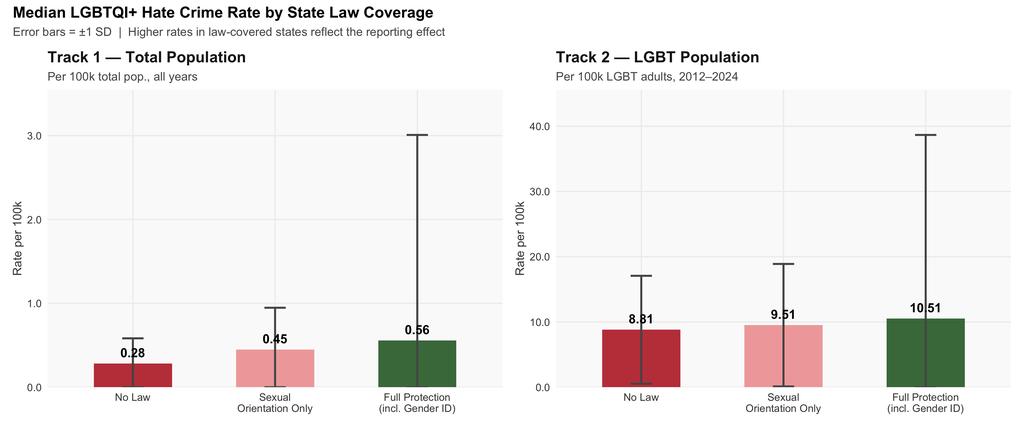

```r
make_law_bar <- function(result, rate_col, title, subtitle) {
  if (is.null(result)) return(NULL)
  d <- result$data |>
    mutate(LAW_LABEL = factor(
      case_when(LAW_LEVEL == 0 ~ "No Law",
                LAW_LEVEL == 1 ~ "Sexual\nOrientation Only",
                LAW_LEVEL == 2 ~ "Full Protection\n(incl. Gender ID)"),
      levels = c("No Law", "Sexual\nOrientation Only", "Full Protection\n(incl. Gender ID)")
    )) |>
    group_by(LAW_LABEL) |>
    summarise(MEDIAN = median(RATE, na.rm=TRUE), SD = sd(RATE, na.rm=TRUE), .groups="drop")

  ggplot(d, aes(x = LAW_LABEL, y = MEDIAN, fill = LAW_LABEL)) +
    geom_col(width = 0.55, alpha = 0.85) +
    geom_errorbar(aes(ymin = pmax(0, MEDIAN - SD), ymax = MEDIAN + SD),
                  width = 0.15, linewidth = 0.8, colour = "#555555") +
    geom_text(aes(label = number(MEDIAN, accuracy = 0.01)), vjust = -0.7, size = 3.8, fontface = "bold") +
    scale_fill_manual(
      values = c("No Law"="#B71C1C", "Sexual\nOrientation Only"="#EF9A9A",
                 "Full Protection\n(incl. Gender ID)"="#1B5E20"), guide = "none") +
    scale_y_continuous(labels = number_format(accuracy = 0.1),
                       expand = expansion(mult = c(0, 0.18))) +
    labs(title = title, subtitle = subtitle, x = NULL, y = "Rate per 100k") +
    theme_hate()
}

p13a <- make_law_bar(tt1, "RATE_PER_100K_TOTAL",
                     "Track 1 — Total Population", "Per 100k total pop., all years")
p13b <- make_law_bar(tt2, "RATE_PER_100K_LGBT",
                     "Track 2 — LGBT Population", "Per 100k LGBT adults, 2012–2024")

if (!is.null(p13a) && !is.null(p13b)) {
  p13 <- p13a + p13b +
    plot_annotation(
      title    = "Median LGBTQI+ Hate Crime Rate by State Law Coverage",
      subtitle = "Error bars = ±1 SD  |  Higher rates in law-covered states reflect the reporting effect",
      theme    = theme(plot.title    = element_text(face = "bold", size = 13),
                       plot.subtitle = element_text(size = 10, colour = "#555555"))
    )
  print(p13)
  save_chart(p13, "13_law_comparison_bar.png", width = 12, height = 5)
} else if (!is.null(p13a)) {
  print(p13a)
  save_chart(p13a, "13_law_comparison_bar.png", width = 8, height = 5)
}
```

## Test 3 — Subgroup Growth Rates (CAGR)

**Compound Annual Growth Rate (CAGR)** compares the first and last year of the dataset per bias category, normalising for the number of years elapsed. Starting values of 0 are floored to 1 to avoid division by zero.

```r
main_cats <- c("Anti-Gay (Male)", "Anti-Lesbian", "Anti-LGBTQ (General)",
               "Anti-Transgender", "Anti-Bisexual")

yr_min <- min(full$YEAR, na.rm = TRUE)
yr_max <- max(full$YEAR, na.rm = TRUE)

cat_ends <- full |>
  filter(BIAS_CATEGORY %in% main_cats) |>
  count(YEAR, BIAS_CATEGORY, name = "INCIDENTS") |>
  filter(YEAR %in% c(yr_min, yr_max)) |>
  pivot_wider(names_from = YEAR, values_from = INCIDENTS, values_fill = 0) |>
  rename(FIRST = 2, LAST = 3) |>
  mutate(
    FIRST        = pmax(FIRST, 1),
    TOTAL_GROWTH = round((LAST - FIRST) / FIRST * 100, 1),
    YEARS_SPAN   = yr_max - yr_min,
    CAGR         = round(((LAST / FIRST)^(1 / YEARS_SPAN) - 1) * 100, 2)
  )

cat_ends |>
  select(BIAS_CATEGORY, FIRST, LAST, TOTAL_GROWTH, CAGR) |>
  arrange(desc(TOTAL_GROWTH)) |>
  knitr::kable(col.names = c("Subgroup", "1991", "2024", "Total Growth %", "CAGR %"),
               caption = sprintf("Subgroup growth rates, %d → %d", yr_min, yr_max))
```

Subgroup growth rates, 1991 → 2024

| Subgroup | 1991 | 2024 | Total Growth % | CAGR % |
| --- | --- | --- | --- | --- |
| Anti-Bisexual | 1 | 39 | 3800.0 | 11.74 |
| Anti-Transgender | 68 | 1127 | 1557.4 | 8.88 |
| Anti-LGBTQ (General) | 1 | 9 | 800.0 | 6.88 |
| Anti-Gay (Male) | 294 | 1077 | 266.3 | 4.01 |
| Anti-Lesbian | 44 | 160 | 263.6 | 3.99 |

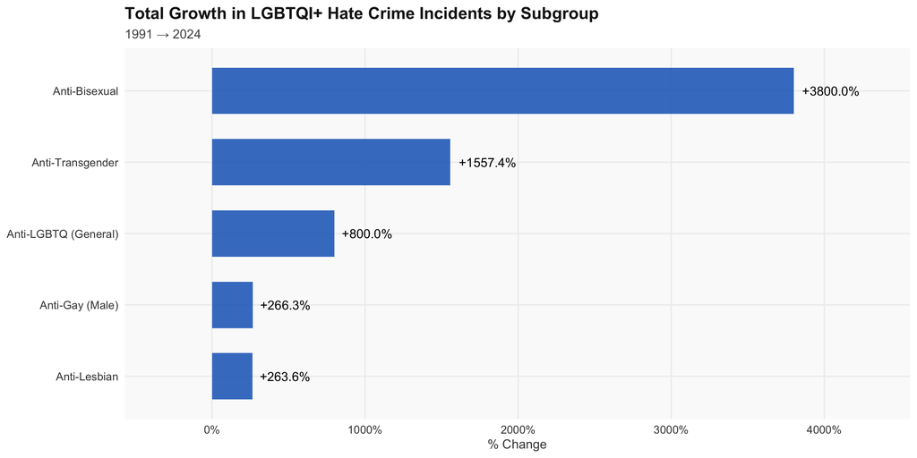

```r
p14 <- ggplot(cat_ends,
              aes(x = fct_reorder(BIAS_CATEGORY, TOTAL_GROWTH),
                  y = TOTAL_GROWTH, fill = TOTAL_GROWTH > 0)) +
  geom_col(width = 0.65, alpha = 0.85) +
  geom_text(aes(label = sprintf("%+.1f%%", TOTAL_GROWTH),
                hjust = ifelse(TOTAL_GROWTH >= 0, -0.15, 1.15)), size = 3.5) +
  coord_flip() +
  scale_fill_manual(values = c("TRUE"="#1565C0","FALSE"="#B71C1C"), guide="none") +
  scale_y_continuous(labels = function(x) paste0(x, "%"),
                     expand = expansion(mult = c(0.15, 0.2))) +
  labs(title    = "Total Growth in LGBTQI+ Hate Crime Incidents by Subgroup",
       subtitle = sprintf("%d → %d", yr_min, yr_max),
       x = NULL, y = "% Change") +
  theme_hate()

p14
```

```r
save_chart(p14, "14_subgroup_growth_rates.png", width = 9, height = 5)
```

## Test 4 — Spearman Correlation Matrix

**Rationale:** Spearman rank correlation is used instead of Pearson because the rate distribution is right-skewed (driven by DC and a few high-density urban states). Spearman is robust to these outliers and monotone non-linear relationships.

```r
build_corr_data <- function(data, rate_col) {
  base <- data |>
    select(STATE_NAME, DATA_YEAR, INCIDENTS, GINI_COEFFICIENT,
           TOTAL_POPULATION, all_of(rate_col)) |>
    rename(RATE = all_of(rate_col))

  if (!is.null(law_lookup)) {
    base <- base |> left_join(law_lookup, by = c("STATE_NAME", "DATA_YEAR"))
  } else {
    base <- base |> mutate(LAW_LEVEL = NA_integer_)
  }

  base |> mutate(LOG_TOTAL_POP = log1p(TOTAL_POPULATION)) |>
    select(RATE, GINI_COEFFICIENT, LOG_TOTAL_POP, LAW_LEVEL) |>
    drop_na()
}

corr_t1 <- build_corr_data(sy, "RATE_PER_100K_TOTAL")
corr_t2 <- build_corr_data(sy |> filter(DATA_YEAR >= 2012), "RATE_PER_100K_LGBT")
```

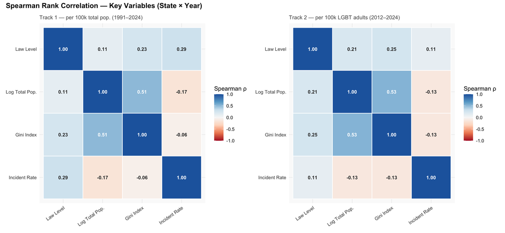

```r
plot_corr_matrix <- function(data, subtitle) {
  corr_labels <- c("Incident Rate", "Gini Index", "Log Total Pop.", "Law Level")
  mat <- cor(data, method = "spearman")
  colnames(mat) <- corr_labels; rownames(mat) <- corr_labels

  mat |>
    as_tibble(rownames = "Var1") |>
    pivot_longer(-Var1, names_to = "Var2", values_to = "RHO") |>
    mutate(Var1 = factor(Var1, levels = corr_labels),
           Var2 = factor(Var2, levels = corr_labels)) |>
    ggplot(aes(x = Var2, y = Var1, fill = RHO)) +
    geom_tile(colour = "white", linewidth = 0.5) +
    geom_text(aes(label = sprintf("%.2f", RHO), colour = abs(RHO) > 0.5),
              size = 3.2, fontface = "bold") +
    scale_fill_distiller(palette = "RdBu", direction = 1, limits = c(-1, 1), name = "Spearman ρ") +
    scale_colour_manual(values = c("TRUE"="white","FALSE"="#333333"), guide="none") +
    scale_x_discrete(limits = rev(corr_labels)) +
    labs(subtitle = subtitle, x = NULL, y = NULL) +
    theme_hate() +
    theme(axis.text.x = element_text(angle = 35, hjust = 1), panel.grid = element_blank())
}

p11a <- plot_corr_matrix(corr_t1, "Track 1 — per 100k total pop. (1991–2024)")
p11b <- plot_corr_matrix(corr_t2, "Track 2 — per 100k LGBT adults (2012–2024)")

p11 <- p11a + p11b +
  plot_annotation(title = "Spearman Rank Correlation — Key Variables (State × Year)",
                  theme = theme(plot.title = element_text(face = "bold", size = 13)))
p11
```

```r
save_chart(p11, "11_correlation_matrix.png", width = 13, height = 6)
```

```r
corr_mat1 <- cor(corr_t1, method = "spearman")
corr_labels <- c("Incident Rate", "Gini Index", "Log Total Pop.", "Law Level")
colnames(corr_mat1) <- corr_labels; rownames(corr_mat1) <- corr_labels
round(corr_mat1, 3) |> knitr::kable(caption = "Track 1 Spearman correlations (1991–2024)")
```

Track 1 Spearman correlations (1991–2024)

|  | Incident Rate | Gini Index | Log Total Pop. | Law Level |
| --- | --- | --- | --- | --- |
| Incident Rate | 1.000 | -0.063 | -0.167 | 0.290 |
| Gini Index | -0.063 | 1.000 | 0.506 | 0.235 |
| Log Total Pop. | -0.167 | 0.506 | 1.000 | 0.115 |
| Law Level | 0.290 | 0.235 | 0.115 | 1.000 |

```r
corr_mat2 <- cor(corr_t2, method = "spearman")
colnames(corr_mat2) <- corr_labels; rownames(corr_mat2) <- corr_labels
round(corr_mat2, 3) |> knitr::kable(caption = "Track 2 Spearman correlations (2012–2024)")
```

Track 2 Spearman correlations (2012–2024)

|  | Incident Rate | Gini Index | Log Total Pop. | Law Level |
| --- | --- | --- | --- | --- |
| Incident Rate | 1.000 | -0.134 | -0.128 | 0.107 |
| Gini Index | -0.134 | 1.000 | 0.529 | 0.246 |
| Log Total Pop. | -0.128 | 0.529 | 1.000 | 0.210 |
| Law Level | 0.107 | 0.246 | 0.210 | 1.000 |

```r
add_result("4. Spearman Rank Correlations — Track 1:", capture.output(print(round(corr_mat1,3))),
           "4. Spearman Rank Correlations — Track 2:", capture.output(print(round(corr_mat2,3))))
```

## Test 5 — OLS Multiple Regression

**Model specification:** `RATE ~ GINI_COEFFICIENT + LOG_TOTAL_POP + LAW_LEVEL + YEAR_C`

`YEAR_C` is the year centred at its mean so the intercept is interpretable. `LOG_TOTAL_POP` is log-transformed to linearise the relationship between population size and rate (larger states have smaller rates partly due to denominator effects). The model is estimated separately for each normalisation track.

```r
build_reg_data <- function(data, rate_col) {
  base <- data |>
    select(STATE_NAME, DATA_YEAR, GINI_COEFFICIENT, TOTAL_POPULATION, all_of(rate_col)) |>
    rename(RATE = all_of(rate_col)) |>
    filter(!is.na(RATE), is.finite(RATE))

  if (!is.null(law_lookup)) {
    base <- base |> left_join(law_lookup, by = c("STATE_NAME", "DATA_YEAR"))
  } else {
    base <- base |> mutate(LAW_LEVEL = 0L)
  }

  base |>
    mutate(LOG_TOTAL_POP = log1p(TOTAL_POPULATION),
           YEAR_C        = DATA_YEAR - mean(DATA_YEAR, na.rm = TRUE)) |>
    drop_na(RATE, GINI_COEFFICIENT, LOG_TOTAL_POP, LAW_LEVEL)
}

run_ols <- function(data, label) {
  m <- lm(RATE ~ GINI_COEFFICIENT + LOG_TOTAL_POP + LAW_LEVEL + YEAR_C, data = data)
  cat(sprintf("\n--- %s ---\n", label))
  cat(sprintf("R² = %.4f | Adj. R² = %.4f | n = %d\n",
              glance(m)$r.squared, glance(m)$adj.r.squared, nobs(m)))
  tidy(m) |>
    mutate(sig = case_when(p.value < 0.001 ~ "***", p.value < 0.01 ~ "**",
                           p.value < 0.05 ~ "*", TRUE ~ "")) |>
    print(n = Inf)
  add_result(sprintf("5. OLS — %s", label),
             sprintf("   R²=%.4f | Adj.R²=%.4f | n=%d", glance(m)$r.squared,
                     glance(m)$adj.r.squared, nobs(m)),
             capture.output(print(tidy(m), n = Inf)))
  m
}

reg_t1 <- build_reg_data(sy, "RATE_PER_100K_TOTAL")
reg_t2 <- build_reg_data(sy |> filter(DATA_YEAR >= 2012), "RATE_PER_100K_LGBT")

ols_t1 <- run_ols(reg_t1, "Track 1 — per 100k total pop. (1991–2024)")
```

```
##
## --- Track 1 — per 100k total pop. (1991–2024) ---
## R² = 0.2828 | Adj. R² = 0.2809 | n = 1533
## # A tibble: 5 × 6
##   term             estimate std.error statistic  p.value sig
##   <chr>               <dbl>     <dbl>     <dbl>    <dbl> <chr>
## 1 (Intercept)      -1.85      0.508       -3.64 2.77e- 4 "***"
## 2 GINI_COEFFICIENT 17.6       1.11        15.9  4.98e-53 "***"
## 3 LOG_TOTAL_POP    -0.393     0.0226     -17.4  6.86e-62 "***"
## 4 LAW_LEVEL         0.306     0.0339       9.02 5.42e-19 "***"
## 5 YEAR_C            0.00239   0.00235      1.02 3.08e- 1 ""
```

```r
ols_t2 <- run_ols(reg_t2, "Track 2 — per 100k LGBT adults (2012–2024)")
```

```
##
## --- Track 2 — per 100k LGBT adults (2012–2024) ---
## R² = 0.2763 | Adj. R² = 0.2717 | n = 630
## # A tibble: 5 × 6
##   term             estimate std.error statistic  p.value sig
##   <chr>               <dbl>     <dbl>     <dbl>    <dbl> <chr>
## 1 (Intercept)       -30.0      12.6      -2.38  1.78e- 2 "*"
## 2 GINI_COEFFICIENT  310.       28.5      10.9   2.65e-25 "***"
## 3 LOG_TOTAL_POP      -6.87      0.550   -12.5   4.18e-32 "***"
## 4 LAW_LEVEL           3.65      0.741     4.92  1.10e- 6 "***"
## 5 YEAR_C              0.119     0.137     0.869 3.85e- 1 ""
```

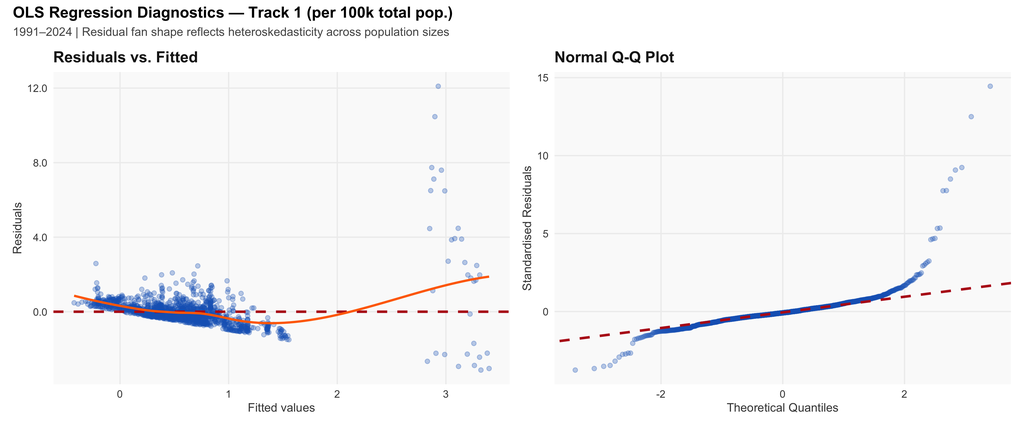

```r
reg_diag <- augment(ols_t1)

p12a <- ggplot(reg_diag, aes(x = .fitted, y = .resid)) +
  geom_point(alpha = 0.3, colour = "#1565C0", size = 1.5) +
  geom_hline(yintercept = 0, colour = "#B71C1C", linewidth = 1, linetype = "dashed") +
  geom_smooth(method = "loess", se = FALSE, colour = "#FF6D00", linewidth = 0.9) +
  scale_y_continuous(labels = number_format(accuracy = 0.1)) +
  labs(title = "Residuals vs. Fitted", x = "Fitted values", y = "Residuals") +
  theme_hate()

p12b <- ggplot(reg_diag, aes(sample = .std.resid)) +
  stat_qq(alpha = 0.3, colour = "#1565C0", size = 1.5) +
  stat_qq_line(colour = "#B71C1C", linewidth = 1, linetype = "dashed") +
  labs(title = "Normal Q-Q Plot",
       x = "Theoretical Quantiles", y = "Standardised Residuals") +
  theme_hate()

p12 <- p12a + p12b +
  plot_annotation(
    title    = "OLS Regression Diagnostics — Track 1 (per 100k total pop.)",
    subtitle = "1991–2024 | Residual fan shape reflects heteroskedasticity across population sizes",
    theme    = theme(plot.title    = element_text(face = "bold", size = 13),
                     plot.subtitle = element_text(size = 10, colour = "#555555"))
  )
p12
```

```r
save_chart(p12, "12_regression_diagnostics.png", width = 12, height = 5)
```

## Test 6 — Chi-Square: Season × Offense Type

**Null hypothesis:** The proportion of violent vs. non-violent incidents is the same across all four seasons.

```r
season_tbl <- full |>
  filter(SEASON %in% c("Spring","Summer","Fall","Winter")) |>
  mutate(
    SEASON      = factor(SEASON, levels = c("Spring","Summer","Fall","Winter")),
    VIOLENT_LBL = if_else(IS_VIOLENT == 1, "Violent", "Non-violent")
  ) |>
  count(SEASON, VIOLENT_LBL) |>
  pivot_wider(names_from = VIOLENT_LBL, values_from = n, values_fill = 0L)

ct_matrix <- season_tbl |> select(-SEASON) |> as.matrix()
rownames(ct_matrix) <- season_tbl$SEASON

chi_test <- chisq.test(ct_matrix)

cat(sprintf("χ² = %.4f  |  df = %d  |  p = %.6f\n",
            chi_test$statistic, chi_test$parameter, chi_test$p.value))
```

```
## χ² = 12.7106  |  df = 3  |  p = 0.005306
```

```r
cat(sprintf("%s\n\n", ifelse(chi_test$p.value < 0.05,
            "✓ Significant: seasonal variation in violence pattern",
            "✗ No significant seasonal variation")))
```

```
## ✓ Significant: seasonal variation in violence pattern
```

```r
cat("Observed counts:\n")
```

```
## Observed counts:
```

```r
print(ct_matrix)
```

```
##        Non-violent Violent
## Spring        5834    5455
## Summer        6653    6441
## Fall          6228    5672
## Winter        4799    4236
```

```r
add_result("6. Chi-Square — Season × Violent/Non-violent",
           sprintf("   χ²=%.4f | df=%d | p=%.6f", chi_test$statistic,
                   chi_test$parameter, chi_test$p.value),
           capture.output(print(ct_matrix)))
```

**Interpretation:** The significant chi-square result (p < 0.05) means that the mix of violent vs. non-violent offenses varies by season — Summer incidents have a slightly higher violent share, consistent with the pattern seen in Chart 08.

## Write Report

```r
writeLines(report_lines, file.path(REPORTS_DIR, "statistical_findings.txt"))
cat("✓ Report saved → reports/statistical_findings.txt\n")
```

```
## ✓ Report saved → reports/statistical_findings.txt
```

```r
cat("  Charts → 11_correlation_matrix.png, 12_regression_diagnostics.png,\n")
```

```
##   Charts → 11_correlation_matrix.png, 12_regression_diagnostics.png,
```

```r
cat("           13_law_comparison_bar.png, 14_subgroup_growth_rates.png\n")
```

```
##            13_law_comparison_bar.png, 14_subgroup_growth_rates.png
```